# GIS R vectors

# Setup

Make sure your have `rgdal`, `rgeos`, `raster`, `ggmap`, `leaflet` and `sp` installed:

```r
library('rgdal')
library('sp')
library('raster')
library('rgeos')
library('leaflet')
library('ggmap')
```

# Spatial (vector) data objects: `sp`

Package `sp` is the central package supporting spatial data analysis in R. `sp` defines a set of classes to represent spatial data. A class defines a particular data type. The `data.frame` is an example of a class. Any particular data.frame you create is an **object** (instance) of that class.

In fact, the `sp` package does not provide many functions to modify or analyse spatial data; but the classes it defines are used in >100 other R packages that provide specific functionalities. The classes `sp` defines are mostly starting with `Spatial*`. For vector data, the basic types are the `SpatialPoints`, `SpatialLines`, and `SpatialPolygons`. These classes only represent **geometries** (i.e. the spatial information). To link the spatial information to a data-table, classes are available with these names plus `DataFrame`, for example, `SpatialPolygonsDataFrame` and `SpatialPointsDataFrame`.

## Geometries

Consider the following vectors with coordinate information:

```r
longitude <- c(4.4543, 5.02789, 4.94202, 4.49238, 4.49054, 4.54044, 5.95192,
               4.49496, 4.4958, 5.68327, 4.49054, 4.49054, 4.4958, 4.48938)
latitude <- c(51.33847, 51.24824, 51.24325, 51.26218, 51.25701, 51.27518,
              51.30803, 51.25803, 51.26106, 51.04185, 51.25701, 51.25701,
              51.26106, 51.25955)
lonlat <- cbind(longitude, latitude)
```

Besides the numbers itself, the variable `lonlat` is not aware of any spatial context (it is just a `matrix` object).

```r
pts <- SpatialPoints(lonlat)
class(pts)
```

```
[1] "SpatialPoints"
attr(,"package")
[1] "sp"
```

We converted the vector to an object of `SpatialPoints`, which contains, beside the matrix data, additional information:

```r
showDefault(pts)
```

```
An object of class "SpatialPoints"
Slot "coords":
      longitude latitude
 [1,]   4.45430 51.33847
 [2,]   5.02789 51.24824
 [3,]   4.94202 51.24325
 [4,]   4.49238 51.26218
 [5,]   4.49054 51.25701
 [6,]   4.54044 51.27518
 [7,]   5.95192 51.30803
 [8,]   4.49496 51.25803
 [9,]   4.49580 51.26106
[10,]   5.68327 51.04185
[11,]   4.49054 51.25701
[12,]   4.49054 51.25701
[13,]   4.49580 51.26106
[14,]   4.48938 51.25955

Slot "bbox":
               min      max
longitude  4.45430  5.95192
latitude  51.04185 51.33847

Slot "proj4string":
CRS arguments: NA
```

So we see that the object has the coordinates we supplied, but also a `bbox`. This is a ‘bounding box’, or the ‘spatial extent’ that was computed from the coordinates. There is also a `proj4string`. This stores the coordinate reference system (CRS). We did not provide the crs so it is unknown (NA). That is not good, so let’s recreate the object, and now provide a crs. We’ll come back to the projection definition later:

```r
crs_wgs84 <- CRS("+init=epsg:4326")
pts <- SpatialPoints(lonlat, proj4string = crs_wgs84)
showDefault(pts)
```

```
An object of class "SpatialPoints"
Slot "coords":
      longitude latitude
 [1,]   4.45430 51.33847
 [2,]   5.02789 51.24824
 [3,]   4.94202 51.24325
 [4,]   4.49238 51.26218
 [5,]   4.49054 51.25701
 [6,]   4.54044 51.27518
 [7,]   5.95192 51.30803
 [8,]   4.49496 51.25803
 [9,]   4.49580 51.26106
[10,]   5.68327 51.04185
[11,]   4.49054 51.25701
[12,]   4.49054 51.25701
[13,]   4.49580 51.26106
[14,]   4.48938 51.25955

Slot "bbox":
               min      max
longitude  4.45430  5.95192
latitude  51.04185 51.33847

Slot "proj4string":
CRS arguments:
 +init=epsg:4326 +proj=longlat +datum=WGS84 +no_defs +ellps=WGS84 +towgs84=0,0,0
```

Hence, the projection information is provided and our geometry is aware of the spatial context.

**Remark**: Assigning a CRS is like labeling something. You need to provide the label that corresponds to the item. Not to what you would like it to be. The latter requires a transformation.

The definition of the geometry as an object of the `SpatialPoints` class, provides a number of spatial functionalities that are not directly available to *default* matrices. As said in the introduction, the `sp` class mainly focuses on the classes (objects) and not on the functionalities. However, an essential functionality provided by `sp` itself (apart from `over` and `aggregate`), is the **transformation of the coordinate reference system (CRS)**:

```r
crs_lambert <- CRS("+init=epsg:31370")
pts_lambert <- spTransform(pts, crs_lambert)
showDefault(pts_lambert)
```

```
An object of class "SpatialPoints"
Slot "coords":
      longitude latitude
 [1,]  155961.2 225412.3
 [2,]  196022.8 215574.7
 [3,]  190031.5 214969.8
 [4,]  158629.2 216928.2
 [5,]  158501.7 216352.8
 [6,]  161980.6 218381.2
 [7,]  260392.8 223200.1
 [8,]  158810.1 216466.8
 [9,]  158868.1 216804.0
[10,]  242186.7 193225.7
[11,]  158501.7 216352.8
[12,]  158501.7 216352.8
[13,]  158868.1 216804.0
[14,]  158420.3 216635.3

Slot "bbox":
               min      max
longitude 155961.2 260392.8
latitude  193225.7 225412.3

Slot "proj4string":
CRS arguments:
 +init=epsg:31370 +proj=lcc +lat_1=51.16666723333333 +lat_2=49.8333339 +lat_0=90 +lon_0=4.367486666666666 +x_0=150000.013 +y_0=5400088.438
+ellps=intl +towgs84=-106.8686,52.2978,-103.7239,0.3366,-0.457,1.8422,-1.2747 +units=m +no_defs
```

Other (geometric) operations are provided by (a huge amount of) additional R Packages. The `rgeos` package is an important package to check for these functionalities. As an example: adding a buffer to our `SpatialPoints` object:

```r
# gbuffer from the rgeos package (see later)
pts_lambert_buffer <- gBuffer(pts_lambert, byid = TRUE, width = 2000)
```

Hence, the result is again a `Spatial*` object, i.e. a `SpatialPolygons` object. A plot of the `pts_lambert` and the `pts_lambert_buffered` together looks as follows:

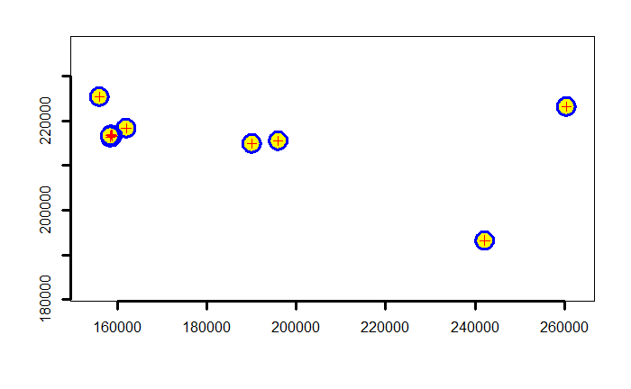

```r
plot(pts_lambert_buffer, border = 'blue',
     col = 'yellow', lwd = 3, axes = TRUE)
plot(pts_lambert, add = TRUE, col = 'red', las = 1)
```

For quick data exploration of such a small data set, an interactive visualization provides better insight. The [leaflet](https://rstudio.github.io/leaflet/) package is well-documented and easy to use, certainly when the `dplyr` piping is familiar to use:

```r
wgs_84 <- CRS("+init=epsg:4326")
wms_hunting <- "https://geoservices.informatievlaanderen.be/raadpleegdiensten/Jacht/wms"
leaflet() %>%   # provide a default openstreetmap background layer to the image
    addCircles(data = pts)  %>% # Add the points to the map
    addPolygons(data = spTransform(pts_lambert_buffer, wgs_84)) %>% # Add the buffer polygons to the map
  addTiles(group = "OSM") %>%
  addWMSTiles(
    wms_hunting,
    layers = "Jachtterr",
    options = WMSTileOptions(format = "image/png", transparent = TRUE)
  )
```

[interactive chart not shown]

**EXERCISE**

Check the [documentation of the leaflet Package](https://rstudio.github.io/leaflet/) and adapt the following items to the leaflet map:  
(1) The coordinates should be replaced by an icon marker instead of just a circle  
(2) The buffers should not be filled and have a red color.

Notice that you can add any available WMS service to the map, by using the proper linkg to the WMS service. Examples are provided in [this tutorial](https://inbo-tutorials.netlify.com/spatial/wms/).

## Spatial***DataFrame

The geometry classes provided by `sp` contain the spatial information, but do not add data to these points (or lines/polygons). The data attribute table is typically provided as a `data.frame`. For this reason, `sp` also provides classes that link the geometries with DataFrames: `SpatialPointsDataFrame`, `SpatialLinesDataFrame` and `SpatialPolygonsDataFrame`.

Let’s assume that for each of the coordinates defined above, we also have information about an `identifier` and a `scientificName`:

```r
identifiers <- c('INBO:NBN:BFN00179000029DL', 'INBO:NBN:BFN001790000A584',
                 'INBO:NBN:BFN001790000AACI', 'INBO:NBN:BFN0017900009DOC',
                 'INBO:NBN:BFN001790000A4J0', 'INBO:NBN:BFN0017900009DO8',
                 'INBO:NBN:BFN001790000AACF', 'INBO:NBN:BFN001790000A4JO',
                 'INBO:NBN:BFN001790000A4K8', 'INBO:NBN:BFN001790000A51G',
                 'INBO:NBN:BFN001790000A4J3', 'INBO:NBN:BFN001790000A4J5',
                 'INBO:NBN:BFN001790000A4K6', 'INBO:NBN:BFN001790000A4L5')
scientific_names <- c('Lagarosiphon major', 'Lagarosiphon major',
                      'Muntiacus reevesii', 'Muntiacus reevesii',
                      'Muntiacus reevesii', 'Muntiacus reevesii',
                      'Muntiacus reevesii', 'Muntiacus reevesii',
                      'Muntiacus reevesii', 'Muntiacus reevesii',
                      'Muntiacus reevesii', 'Muntiacus reevesii',
                      'Muntiacus reevesii', 'Muntiacus reevesii')
recorded <- as.data.frame(cbind(identifiers, scientific_names))
head(recorded)
```

[output not shown]

Hence, the `SpatialPointsDataFrame` combines the spatial information (`pts_lambert`) with the recorded data (`recorded`):

```r
pts_recorded <- SpatialPointsDataFrame(pts_lambert, data = recorded)
pts_recorded
```

[output not shown]

For the moment, the take home message is that `Spatial***DataFrame` bring together the attribute data (`data.frame`), the coordinates (`geometry`) and the coordinate reference system (`crs`):

```r
head(pts_recorded@data)
```

```r
head(pts_recorded@coords)
```

```r
pts_recorded@proj4string
```

## Projection

```r
CRS("+proj=utm +zone=32")
```

In general, the definition of the CRS (input argument) should ba a string setup up by one or more `+<arg>=<value>` combinations, each of them separated by a blank value: `+<arg1>=<value1> +<arg2>=<value2>`. The CRS-creation returns an object (with a variable name you can assign):

```r
wgs_84 <- CRS("+init=epsg:4326")
wgs_lambert <- CRS("+init=epsg:31370")
wgs_84
wgs_lambert
```

```r
single_coordinate <- SpatialPoints(matrix(c(98710.32800000161,
                                            162573.7030000016),
                                          ncol = 2),
                                   proj4string = wgs_lambert)

spTransform(single_coordinate, wgs_84)
```

The application is similar to other spatial objects, such as a `SpatialPointsDataFrame`:

```r
pts_recorded_wgs84 <- spTransform(pts_recorded, wgs_84)
pts_recorded_wgs84
```

**EXERCISE**

As your regularly encounter point coordinates that need conversion to another projection system, you decide to make a functions for future use:

For any `data.frame`(!) with coordinate information in a known coordinate reference system, update the columns with the x/y information to another coordinate system. The function returns the updated `data.frame`.

The function will probably look more or less like this:

```
reproject_points <- function(df, col_long, col_lat,
                             project_input, project_output){
    # ...

    return(df)
```

Following test should be able to work with the `reproject_points` function:

```r
pts_ex2_test <- as.data.frame(pts_recorded)
ex2_test <- reproject_points(pts_ex2_test, "longitude", "latitude",
                             CRS("+init=epsg:31370"),
                             CRS("+init=epsg:4326"))
head(ex2_test)
```

**Remark:** This function is part of the [`inborutil` package,](https://inbo.github.io/inborutils) and can be used by installing the package. Another - related - function helps you to guess a given projection of a given data set, when no CRS information is provided. The `guess_projection` function creates a *leaflet* plot with the coordinates in a variety of predefined coordinate reference systems.

# Reading data: `rgdal`

Mostly, the starting point of a data analysis involving spatial data is a data set in any kind of GIS format. The functionality to read **vector** data is provide by the `readOGR` function or the `rgdal` package:

```r
deelbekkens <- readOGR("../data/deelbekkens/Deelbekken.shp")
```

```r
deelbekkens
```

```r
plot(deelbekkens)
```

Besides shapefiles, other vector data formats can be read as well. Certainly `geojson` is a increasingly used data format for feature (vector) data sets:

```r
eu_10grid <- readOGR("../data/EUgrid10.geojson")
```

```r
eu_10grid
```

Actually, the set of data formats you can interact with, *does not depend on R*, but is dependent on your GDAL installation. To check if the installation supports a specific **vector** data format, you can get an overview of them by the `ogrDrivers()` command:

```r
head(ogrDrivers()) # Just the first 6 records are shown here
```

For data sets with multiple layers, the reading of a specific Layer is supported as well. For example, when the driver to read ESRI FileGeoDatabases is present, following commands will be useful as well:

```r
# Information about the data (without actually reading the data itself)
ogrInfo(dsn = "name_filegeodatabase.gdb")
# List the names of the layers in the dataset
ogrListLayers(dsn = "name_filegeodatabase.gdb")
# Reading a specific layer
readOGR(dsn = "name_filegeodatabase.gdb", layer = "layer_of_interest"
```

# Vector data manipulation

## DataFrame alike manipulation

Vector data represented as `Spatial***DataFrame` can be sub selected as a DataFrame. For example, selecting only the `deelbekkens` that are in the `Netebekken` (Boolean indexing):

```r
nete <- deelbekkens[deelbekkens$BEKNAAM == "Netebekken", ]
plot(nete)
```

The result of the selection is again a `SpatialPolygonsDataFrame`. When only interested in the data itself, the selection of the attribute data alone can be done by converting the data to a DataFrame.

```r
head(as.data.frame(nete))
```

Hence, the geometry and projection data is no longer contained, only the data itself.

**Remark:** The `sp` data types do NOT support the `dplyr` package. If you want to use the `%>%` operator and the *verbs* such as `filter`, `mutate`,… as used in the `dplyr` package, you could start using the [`sf` package](https://cran.r-project.org/web/packages/sf/index.html), the newest package setup with the `tidyverse` environment in mind. [This introduction](http://strimas.com/r/tidy-sf/) and the [documentation of](https://github.com/edzer/sfr) of `sf` is good to start.

## `sp` overlay and aggregations

The `sp` package provides mostly the data types. However, the `spTransform` function is an essential function provided by the package itself. Two other functions of the `sp` package are worth mentioning:

- `disaggregate`: groups of `Line` or `Polygon` (multi) are disaggregated to one `Line`/`Polygon` for each feature. When applied to the `deelbekkens` data set:

```r
length(deelbekkens)
deelbekkens_disaggr <- disaggregate(deelbekkens)
length(deelbekkens_disaggr)
```

- `over(x, y)` is used for spatial JOINs

```r
ids <- over(spTransform(eu_10grid, wgs_lambert), pts_recorded)
ids <- na.omit(ids)
ids
```

**Remark** `Lines`, and `Polygon`-`Polygon` overlays require `rgeos`.

Check the vignette (`vignette('over')` in console) to get more details about all the different spatial JOIN options with the `sp` package. On the other hand, the `sf` package interface for spatial joins is more intuitive. This [point-in-polygon example](https://gist.github.com/stijnvanhoey/7b51017718834f150f781a256292904e#file-spatial_join-r) compares the `sp` and the `sf` implementation.

## `rgeos` geometry operations

The `rgeos` package provide a number of geometric operations, such as `gArea()`, `gLength()`, `gDistance()`, `gBuffer()`,… (single geometry) or `gIntersection()`, `gUnion()`, `gContains`,… (combining geometries).

As most commands of rgeos start with g***, use the power of the TAB-button to explore the available functions of the `rgeos` package: `rgeos::g` + TAB

These functions operate both on `Spatial*` objects (see above) as well as `Spatial***DataFrame` objects. Most of these functions speak for themselves (or read the manual). An important argument of these functions is `byid`. The `byid` argument determines if the function should be applied across sub geometries (`TRUE`) or the entire object (`FALSE`). Default is `FALSE`. For example, for the `area` calculation:

```r
gArea(nete) # default is FALSE -> entire object
```

versus

```r
gArea(nete, byid = TRUE)
```

Comparison of geometries involves two geometries:

```r
vertical <- eu_10grid[grep('E400', eu_10grid$CellCode), ]
horizontal <- eu_10grid[grep('N311', eu_10grid$CellCode), ]

comparison <- gContains(vertical, horizontal,
                        byid = TRUE, checkValidity = TRUE,
                        returnDense = TRUE) # Test also with gIntersects
true_ids <- as.data.frame(which(comparison, arr.ind = TRUE)) # Find the TRUE elements
true_ids
```

[output not shown]

```r
# adjusting the colors transparency
blue <- adjustcolor("blue", alpha.f = 0.3)
red <- adjustcolor("darkred", alpha.f = 0.3)

# plot the cells selected by the geometry comparison:
plot(vertical)
plot(vertical[true_ids$col,], add = TRUE, col = blue)
plot(horizontal, add = TRUE)
plot(horizontal[true_ids$row,], add = TRUE, col = red)
```

**EXERCISE**

Make a `leaflet` plot (with open street map background) of the `nete` sub catchments, together with the `Centroid` for each of the sub geometries.

**Tip 1:** Looking for a command that matches the action `centroid` in R, is done by using `??centroid` in the Console.  
**Tip 2:** Remember that leaflet always expects WGS84 as CRS to make a plot(!)

# Mapping vector data

## `ggplot`

When working with DataFrame data, the application of `ggplot2` is typical. Hence, it would be convenient to use `ggplot2` (and the syntax) to plot `Spatial***DataFrame` as well. As `ggplot2` only works on `data.frame` objects, a translation need to be made between the `Spatial***DataFrame` and a default `data.frame`.

For `SpatialPointsDataFrame` this is not really an issue, as the `longitude` and `latitude` columns provide the geometry information and can be used as such in `ggplot` by directly converting the data to a `data.fram`

```r
pts_recorded_df <- as.data.frame(pts_recorded)
pts_recorded_df
```

```r
ggplot(pts_recorded_df, aes(x = longitude, y = latitude)) +
    geom_point() +
    geom_text(size = 4, aes(label = scientific_names),
              check_overlap = TRUE, hjust = -0.1) +
    xlim(150000, 300000)
```

For `Lines` and `Polygons`, the translation requires an entire interpretation of the configuration towards a `data.frame`. This functionality is provided by `fortify`, which translates the **spatial** information:

```r
nete_df <- fortify(nete)
head(nete_df)
```

[output not shown]

```r
class(nete_df)
```

The individual columns of the resulting `data.frame` describe the following elements:

- `long` and `lat`: x and y coordinates
- `order`: sequence of the polygones or lines
- `hole`: identifies whether the feature the coordinates are part of define a hole
- `piece`: collects all the points that make a single feature (polygon/line), i.e. 1 attributes table line • `group`: defines the subpolygons or sublines (in case of multipolygon/multiline features) • `id`: row identifiers of the attribute table (data)

Still, the added value of using `ggplot2` is to use the attribute data to define colors,… As the attribute data table is available and we have an identifier `id`, we can JOIN the attribute data to the spatial information after retrieving the **attribute** data with the `as.data.frame` function:

```r
nete_df <- merge(nete_df, as.data.frame(nete))
head(nete_df)
```

**REMEMBER**

In order to plot `SpatialLinesDataFrame` or `SpatialPolygonsDataFrame` data, the **spatial data** (with `fortify()`) need to be merged with the **attribute data** (with `as.data.frame`) to have a `ggplot2` compatible `data.frame`!

This seems to be a useful small tooling for a custom R function…

**EXERCISE**

Write a function called `prepare_spatial_for_ggplot` that takes a `SpatialLinesDataFrame` or `SpatialPolygonsDataFrame` as input and execute the necessary steps (described above: `fortify`/`as.data.frame`/`merge`) to enable the plotting with `ggplot2`. The output of the function is a `data.frame`.

Following test should be able to work with the `prepare_spatial_for_ggplot` function:

```r
ex4_test <- prepare_spatial_for_ggplot(nete)
head(ex4_test)
```

For plotting `Lines`, use the `ggplot` function `geom_path()` (and NOT `geom_line()`). For polygons, you can choose: * `geom_path()`: only plot the borders * `geom_polygon()`: usa a fill color for the polygons

```r
ggplot(nete_df, aes(x = long, y = lat)) +
    geom_polygon(aes(group = group, fill = id)) +
    coord_fixed()
```

**Remark:** Adding `group = group` (grouping according to the by fortify derived groups) is required to plot the individual polygons separately(!)

Starting from ggplot2 version 2.2.1, the plotting of spatial objects defined in the `sf` package will no longer need this transformation, but will directly provide the `geom_sf` function to plot vector data in `ggplot2`, see [the documentation](http://ggplot2.tidyverse.org/reference/ggsf.html)!

## `ggmap`

The `ggmap` package is the spatial plotting extension to `ggplot2`. It provides the ability to integrate the graphs of `ggplot2` with spatial backgrounds coming from online resources such as Google maps, [stamen maps](http://maps.stamen.com/#terrain/12/37.7706/-122.3782) and OpenStreetMap. The most convenient way to setup these background maps is to use the `ggmap::get_***` functions. For example, using the `toner-background` of stamen:

```r
extent <- c(left = 2.54, bottom = 49.46, right = 6.4, top = 51.51)
map <- get_stamenmap(extent, zoom = 8, maptype = "toner-background")
belgium <- ggmap(map)
belgium
```

Just as with the OpenStreetMap integration of the `leaflet` package, these spatial background coming from online resources use `WGS84` (decimal degrees). Make sure to convert the vector data to the WGS84 `CRS`:

```r
nete_wgs84 <- spTransform(nete, wgs_84)
nete_df_wgs84 <- fortify(nete_wgs84)
nete_df_wgs84 <- merge(nete_df_wgs84, as.data.frame(nete_wgs84))

belgium +
    geom_path(aes(x = long, y = lat, group = group),
          data = nete_df_wgs84, colour = "red")
```

The `bbox` can be defined more specifically to improve the boundaries of the background image. Focusing on the Nete catchment:

```r
extent <- c(left = 4.42, bottom = 50.9, right = 5.4, top = 51.4)
map <- get_stamenmap(bbox = extent, zoom = 10, maptype = "toner-hybrid")
ggmap(map) +
    geom_path(aes(x = long, y = lat, group = group),
              data = nete_df_wgs84, colour = "red")
```

**Remark:** each of these online providers have different `maptype` options. Check the help of these functions to see the options (e.g. `?get_stamenmap`).

The usage of Google maps enables the option to provide a *google maps search* as center of the image

```r
map <- get_googlemap(center = "Geel Belgium",  scale = 2,
                     maptype = "terrain", zoom = 9)
ggmap(map) +
    geom_polygon(aes(x = long, y = lat, group = group, fill = id, alpha = 0.5),
          data = nete_df_wgs84, colour = "white")
```

The [Github repository](https://github.com/dkahle/ggmap) and [the paper](https://journal.r-project.org/archive/2013-1/kahle-wickham.pdf) provide more introductionary material to get you started with `ggmap`. Another potentially useful plotting package is the [`tmap`](https://cran.r-project.org/web/packages/tmap/vignettes/tmap-nutshell.html) package.

**EXERCISE**

Pick **any spatial vector** data set (shapefile, geojson,…) currently on your computer:

1. `read` the file into R as a Spatial***DataFrame
2. make a subselection of the dataset using one of the data columns and a condition (e.g. `length > 10000`)
3. create a `ggplot` with the color of each spatial entity defined by a chosen data columns